# Labyrinthes

## 5. Résolution des labyrinthes ciruclaires

Bon bah là pas de mystère, on a à notre disposition la liste des liaisons (des murs) de notre labyrinthe donc comme pour les labyrinthes carrés :

- parcours en largeur
- retour sur le chemin

Et on a une solution 😎

On va tout d'abord faire une fonction pour obtenir les voisins d'un point. Prenons également une labyrinthe fixé pour faire nos tests :

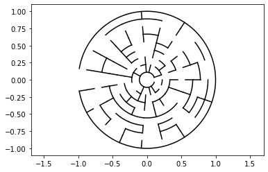

```python
nb_anneau = 8
nb_separation = 19 #prendre un nombre impaire !!
test_maze = create_circle_maze(nb_anneau,nb_separation)
```

```python
%%time

def voisins(i,j):
    V = []
    if j == 0:
        V.append((i,1))
        V.append((i,nb_separation-1))
    elif j == nb_separation-1:
        V.append((i,j-1))
        V.append((i,0))
    else:
        V.append((i,j+1))
        V.append((i,j-1))

    if i == 0:
        V.append((1,j))
    elif i == nb_anneau-1:
        V.append((i-1,j))
    else:
        V.append((i+1,j))
        V.append((i-1,j))
    return V
voisins(0,0)
```

```
CPU times: user 39 µs, sys: 1 µs, total: 40 µs
Wall time: 44.8 µs
```

```
[(0, 1), (0, 18), (1, 0)]
```

Pour faire notre parcours en largeur on va recréer une matrice vide et se balader dedans.

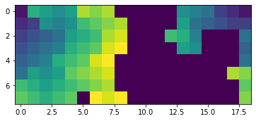

```python
CR = empty_maze(nb_anneau,nb_separation)

to_visit = [[(0,0),(0,nb_separation-1)]]
distance = 1

while not((nb_anneau-1,nb_separation//2) in to_visit[distance-1]):
    distance += 1
    tmp = []
    for coords in to_visit[distance-2]:
        i,j = coords
        CR[i][j] = distance-1

    for coords in to_visit[distance-2]:
        i,j = coords
        V = voisins(i,j)

        for c in V:
            a,b = c
            if CR[a][b] == 0:
                if not(((a,b),(i,j)) in test_maze) and not(((i,j),(a,b)) in test_maze):
                    tmp.append(c)
    to_visit.append(tmp)

plt.imshow(CR)
```

```python
print(np.array(CR))
```

```
[[ 1 10  9  8  9 14 13 14  0  0  0  0  0  8  7  6  3  2  1]
 [ 2  3  8  7  8 11 12 13 14  0  0  0  0  9  6  5  4  3  3]
 [ 3  4  5  6  9 10 11 14 15  0  0  0 11 10  7  0  0  0  6]
 [ 4  5  6  7 10 11 12 15 16  0  0  0  0  9  8  0  0  0  5]
 [ 5  6  7 10 11 12 15 16  0  0  0  0  0  0  0  0  0  0  6]
 [ 6  9  8  9 12 13 14 15  0  0  0  0  0  0  0  0  0 14 13]
 [11 10  9 10 11 12 13 14  0  0  0  0  0  0  0  0  0  0 12]
 [12 11 10 11 12  0 16 15 16  0  0  0  0  0  0  0  0  0 13]]
```

Comme on l'avait dit précédemment, on pouvait faire la fonction de retour sur le chemin de façon récurcive, c'est ce qu'on a fait là !

```python
def aux_chemin_circle(t):
    if t[1] == 0 or t[1] == 1:
        return (nb_separation)**5
    else:
        return t[1]

def chemin_circle(pos):
    i,j = pos
    if CR[i][j] == 2:
        return [(0,0),(0,nb_separation-1),(i,j)]
    else:
        V = []
        for d in voisins(i,j):
            a,b = d
            if not(((a,b),(i,j)) in test_maze) and not(((i,j),(a,b)) in test_maze):
                V.append([(a,b),CR[a][b]])
        c = (sorted(V,key=aux_chemin_circle))[0][0]
        return chemin_circle(c)+[pos]

C = chemin_circle((nb_anneau-1,nb_separation//2))
```

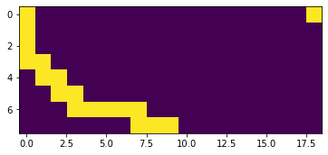

```python
CR = empty_maze(nb_anneau,nb_separation)
for coords in C:
    a,b = coords
    CR[a][b] = 2
plt.imshow(CR)
```

```python
C
```

```
[(0, 0),
 (0, 18),
 (1, 0),
 (2, 0),
 (3, 0),
 (3, 1),
 (4, 1),
 (4, 2),
 (5, 2),
 (5, 3),
 (6, 3),
 (6, 4),
 (6, 5),
 (6, 6),
 (6, 7),
 (7, 7),
 (7, 8),
 (7, 9)]
```

Maintenant qu'on a obtenu notre chemin, on l'affiche dans notre labyrinthe et le tour est joué :

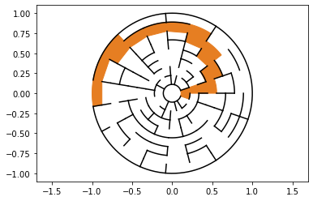

```python
ND = 32*nb_separation
cercle = reg_poly(ND)
cercle2 = reg_poly(ND,(nb_separation-1)/nb_separation)

def print_cell_chemin(i,j):

    plt.fill(
        [
            cercle[0,j*(ND//nb_separation)]*(i+1)/(nb_anneau+1),
            cercle[0,j*(ND//nb_separation)]*(i+2)/(nb_anneau+1)
        ]+
        (cercle[0,j*(ND//nb_separation):(j+1)*(ND//nb_separation)+1]*(i+2)/(nb_anneau+1)).tolist()
        +[
            cercle[0,(j+1)*(ND//nb_separation)]*(i+2)/(nb_anneau+1),
            cercle[0,(j+1)*(ND//nb_separation)]*(i+1)/(nb_anneau+1)
        ]+
        (cercle[0,(j+1)*(ND//nb_separation):j*(ND//nb_separation)+1]*(i+1)/(nb_anneau+1)).tolist(),
        [
            cercle[1,j*(ND//nb_separation)]*(i+1)/(nb_anneau+1),
            cercle[1,j*(ND//nb_separation)]*(i+2)/(nb_anneau+1)
        ]+
        (cercle[1,j*(ND//nb_separation):(j+1)*(ND//nb_separation)+1]*(i+2)/(nb_anneau+1)).tolist()
        +[
            cercle[1,(j+1)*(ND//nb_separation)]*(i+2)/(nb_anneau+1),
            cercle[1,(j+1)*(ND//nb_separation)]*(i+1)/(nb_anneau+1)
        ]+
        (cercle[1,(j+1)*(ND//nb_separation):j*(ND//nb_separation)+1]*(i+1)/(nb_anneau+1)).tolist(),
        color="#e67e22"
    )


for c in C:
    i,j = c
    print_cell_chemin(i,j)


plt_circle_maze(test_maze,nb_anneau,nb_separation)
```

RQ : si on veut faire un labyrinthe sur un tore il ne tient qu'à nous de créer la liaisons bas en haut et paf...

## 6. Des labyrinthes à la main ?

Pour résoudre des labyrinthes à la main on va se servir de nos codes précédent. On va tout d'abord couvertir la photo en un matrice composé de 0 et de 1 pour les murs et les chemins.

Puis on va choisir un point de départ et d'arrivé et finalement on va chercher une solution.

On se basera sur le labyrinthe suivant (manifiquement déssiné), que l'on a coupé :

```python
image = cv2.imread('./20201220_164947cut.png')
image = cv2.cvtColor(src=image, code=cv2.COLOR_BGR2GRAY)
```

```python
image.shape
```

```
(2448, 2632)
```

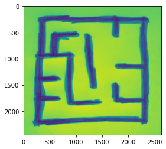

```python
plt.imshow(image)
```

```python
image2 = copy.deepcopy(image)
```

```python
s = 100

image2[image2 > s] = 150
image2[image2 <= s] = 0
```

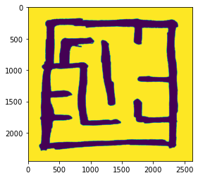

```python
plt.imshow(image2)
```

On va créer une fonction qui nous importe notre image et nous la prépare. De plus on est obligé d'utiliser une fonction de rescaling pour avoir moins de pixels et pouvoir traiter notre labyrinthe.

```python
def prepare_img(imglink):
    img = cv2.imread(imglink)
    img = cv2.resize(img, (25,27),interpolation=cv2.INTER_NEAREST)
    img = cv2.cvtColor(src=img, code=cv2.COLOR_BGR2GRAY)
    img[img > 100] = 150
    img[img <= 100] = 0
    img[img == 150] = 1
    return img
```

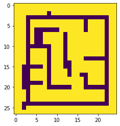

```python
image = prepare_img('./20201220_164947cut.png')
plt.imshow(image)
```

Attention le code qui suit prend un peu de temps à compiler :

```python
image_col = copy.deepcopy(image)

debut = (4,5)
fin = (22,20)

to_visit = [[debut]]
distance = 1

while not(fin in to_visit[distance-1]):
    distance += 1
    tmp = []

    for coords in to_visit[distance-2]:
        i,j = coords
        image_col[i][j] = distance

    for coords in to_visit[distance-2]:
        i,j = coords
        for c in [(i-1,j),(i+1,j),(i,j-1),(i,j+1)]:
            a,b = c
            if image_col[a][b] == 1:
                tmp.append(c)
    to_visit.append(tmp)
```

[output not shown]

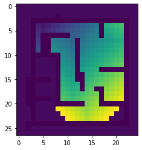

```python
plt.imshow(image_col)
len(to_visit)
```

```python
C = get_chemin(debut,fin,image_col)

travel_chemin(image,C)
```

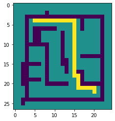

```python
plt.imshow(image)
```

## 7. Rajoutons quelques missions à effectuer

Tel le jeu pacman on va rajouter des fruits sur le chemin, ce seront des points qu'il faudra atteindre avant d'aller à la fin.

Pour celà on va d'abord prendre simplement un labyrinthe carré.

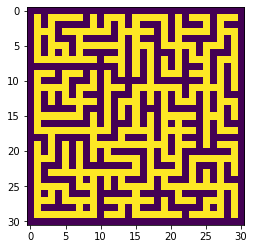

```python
size = 31
M3 = create_square_maze(size,size)
plt.imshow(M3)
```

```python
n = 10
fruits = []

while len(fruits) < n:
    i = rd.randint(0, size//2-1)
    j = rd.randint(0, size//2-1)
    if not((i,j) in fruits):
        fruits.append((1+2*i,1+2*j))

print(fruits)
```

```
[(7, 13), (11, 11), (15, 3), (5, 9), (1, 29), (11, 3), (13, 25), (13, 7), (15, 11), (19, 25)]
```

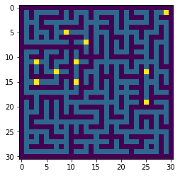

```python
L3 = copy.deepcopy(M3)

for (i,j) in fruits:
    L3[i][j] = 3

plt.imshow(L3)
```

```python
def get_chemin_from_maze(start,end,M):
    N = copy.deepcopy(M)
    travel_maze_for_distance(start,end,N)
    C = get_chemin(start,end,N)
    return C
```

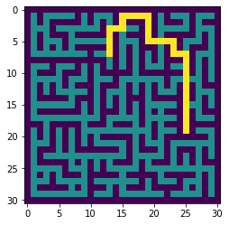

```python
R3 = copy.deepcopy(M3)
C = get_chemin_from_maze(fruits[0],fruits[-1],R3)
travel_chemin(R3,C)
plt.imshow(R3)
```

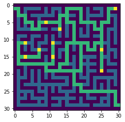

```python
F3 = copy.deepcopy(M3)

points_a_voir = [(1,1)]+fruits+[(size-2,size-2)]

C = []
for k in range(len(points_a_voir)-1):
    test_travel = False
#petite manigeance pour supprime certains chemins si on a déjà le points sur le chemin
    if k > 0 and k < (len(points_a_voir)-1):
        if not(points_a_voir[k+1] in C):
            test_travel = True
    else:
        test_travel = True

    if test_travel:
        C += get_chemin_from_maze(points_a_voir[k],points_a_voir[k+1],F3)
travel_chemin(F3,C)
for fruit in fruits:
    i,j = fruit
    F3[i][j] = 3
F3[1][0] = 2
F3[size-2][size-1] = 2
plt.imshow(F3)
```

Ce n'est pas forcément le chemin le plus court mais ça nous donne au moins un chemin.

Voilà c'est fini.